# Mineralization in STICS

B. Mary H. Clivot, D. Ripoche

June 1, 2017 (update October 16, 2018)

*Mineralization of soil organic matter* Carbon and nitrogen mineralization of soil organic matter (SOM) is associated with SOM decomposition. STICS distinguishes the decomposition of stabilized SOM (called humus) and decomposition of exogenous organic matter such as crop residues, manures, and so on… Decomposition of humified SOM takes place mainly in the upper layer of soil. Although the soil below the tilled depth and the subsoil may contain important reserves of organic C and N, their decomposition rate appears to be slow compared to the upper soil layer (e.g. Clivot et al., 2017). In STICS, mineralization is assumed to occur down to a maximum depth (profhum, in cm) and be negligible below this depth. The N mineralization rate (Vminh, in kg N ha-1 day-1 in eq. 1) depends on the amount of active soil organic nitrogen (Nhum, in kg N ha-1, calculated in eq. 2) over this depth, some soil properties (clay content, calcium carbonate content, …) and environmental factors, namely the water content and temperature in each soil layer (factors FH and FTH).

$$Vminh(I)=K2(I)*Nhum(I) \hspace{10cm} (1)$$

$$Nhum(I)=Norg*(1-Finert)*DA(1)*profhum\hspace{5.3cm} (2)$$
Nhum at the beginning of simulation is the product of organic nitrogen content in the upper layer (Norg, in %), the proportion of active organic nitrogen (1-Finert), the bulk density of the upper layer(DA(1), in g cm-3) and the thickness of the biologically active layer (profhum, in cm). The default value for Finert is 0.65. Nhum varies throughout time.

$$K2(I)=K2pot *\frac{ \sum_ {z=1}^{profhum} FH(Z,I)* FTH(Z,I)}{profhum}\hspace{6.3cm} (3)$$

K2 is the actual mineralization rate constant (day-1, eq. 3). K2pot is the potential mineralization rate constant (day-1), i.e. the mineralization rate constant of a soil maintained at the reference values of temperature (Tref = 15°C) and soil moisture content (field capacity). **We propose a new equation to calculate K2pot.**

# 1 Options, variables, parameters

## 1.1 Options Choice

This table summarizes the available options. Formalism and parameters are detailed below (the parameter values are the advised values; we recommend to test the model before changing them). The option activation and the parameters are present in the `param_newform.xml` file. The parameters for the old option are present in the `param_gen.xml` file, in the part “Soil C and N processes and fertiliser losses”.

| Option | Parameter | Default value | Description |
| --- | --- | --- | --- |
| Mineralization model of humified organic matter | `codevminh` | **1** | **1** = new function (Clivot et al, 2017) ; **2** = old function (Delphin, 1986; Chaussod et al, 1986) |

the default option proposed here is the new function described below

## 1.2 input and output variables

| Type | List |
| --- | --- |
| input variables | argi, pH, calc, CsurNsol , profhum |
| input_output variables | amm, nit, Qminh, tnhc, Nhum, Nhumt, Chumt |
| local variables | K2pot, fh, fth, K2, vminh, tnh, vminh |

## 1.3 Parameters

### 1.3.1 old formalism

Parameters for the first option

[output not shown]

### 1.3.2 new formalism

Parameters for the new option (the default one)

| Parameter | Default value | Unit | Description | File | relative to the option |
| --- | --- | --- | --- | --- | --- |
| `gmin1` | 0.00070 | day-1 | parameter describing the effect of soil organic N content | `param_newform.xml` | `codevminh =1` |
| `gmin2` | 0.0252 | %-1 | parameter describing the effect of clay content | `param_newform.xml` | `codevminh =1` |
| `gmin3` | 0.0111 | %-1 | parameter describing the effect of CaCO3 content | `param_newform.xml` | `codevminh =1` |
| `gmin4` | 0.112 | pH-1 | parameter 1 describing the effect of pH | `param_newform.xml` | `codevminh =1` |
| `gmin5` | 8.50 | pH | parameter 2 describing the effect of pH (optimum pH value) | `param_newform.xml` | `codevminh =1` |
| `gmin6` | 0.060 | nd | parameter 1 describing the effect of soil C/N | `param_newform.xml` | `codevminh =1` |
| `gmin7` | 11.00 | nd | parameter 2 describing the effect of soil C/N (optimum C/N value) | `param_newform.xml` | `codevminh =1` |

# 2 Formalisms

## 2.1 Mineralization of soil organic matter : calculation of potential rate of mineralization k2hum

The potential rate of mineralization (K2pot) depends on the mineralogic clay content (argi, in %) and the CaCO3 content (calc, in %). It involves three parameters: fmin1`G`, fmin2`G`, fmin3`G` in the first option, and 7 parameters in the second option gmin1`G`, gmin2`G`, gmin3`G`, gmin4`G`, gmin5`G`, gmin6`G`,gmin7`G`,

### 2.1.1 old equation based on soil incubation data obtained by Delphin (1986) and Chaussod et al (1986)

The potential rate of mineralisation depends on the mineralogic clay content( argi in %) and the CaCO3 content (calc in %) . it involves 3 parameters, option `codevminh`= 2. The function is :
$$k2pot = fmin1 *\frac{ e^{-fmin2 * argi } }{1. + fmin3 * calc}\hspace{10cm} (4)$$

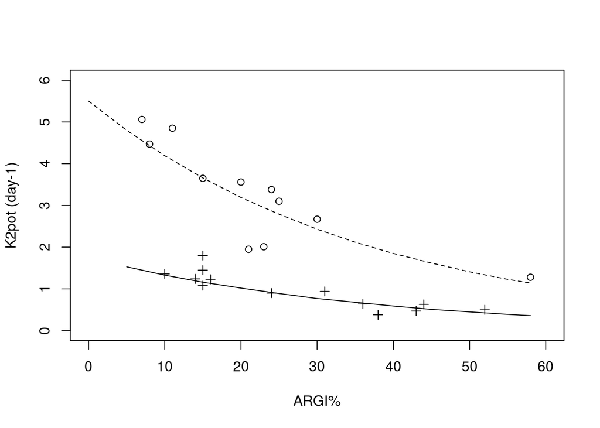

### 2.1.2 New equation (Clivot et al, 2017)

The potential rate of mineralisation Vp depends on the mineralogic clay content( argi in %), the CaCO3 content (calc in %), the soil pH (pH) and the C to N ratio of soil humus (CsurNsol). It involves 7 parameters (`codevminh`= 1), the equation is :

$$k2pot = gmin1 * \frac{ e^{-gmin2*argi}}{(1. + gmin3*calc)} * e^{-gmin4*(pH-gmin5)^2} * (0.8*e^{-gmin6*(CsurNsol-gmin7)^2}+0.2)\hspace{0.5cm} (5)$$

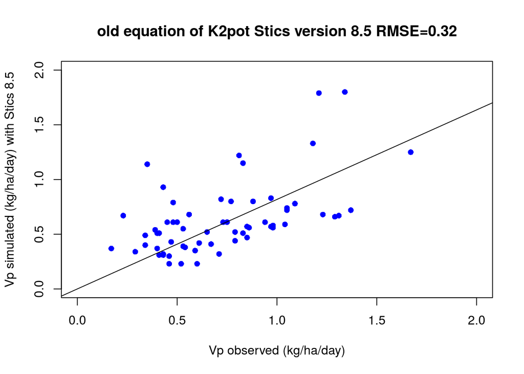

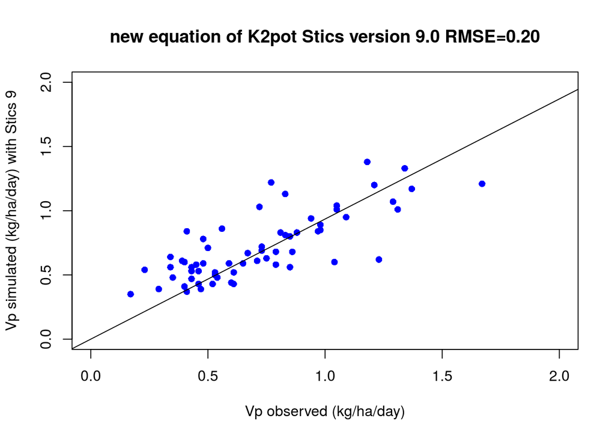